# Proyecto Final - A00820629

2026-03-20

```r
library(quantmod)
```

##PROYECTO FINAL : Se nos está solicitando realizar un análisis para poder modelar el compartamiento de las siguientes acciones así como poder cotejar si el modelo es correcto para predecir el comportamiento de las mismas individualmente.

## MODELOS DE REGRESIÓN

##La acción principal que estuvimos analizando es ##Dependiente: 0. Bank of America BAC y ##Independientes: 1.JPMorgan Chase JPM, 2. Citigroup C, 3. Wells Fargo WFC, 4. Goldman Sachs GS, 5. The Bank of New York Mellon BK, 6. Walmart WMT, 7. Johnson & Johnson JNJ, 8. Lennar Corporation LEN, 9. Prologis, Inc. PLD, 10. Kraft Heinz KHC, 11. NextEra Energy NEE, 12.General Electric GE, 13. American Water Works AWK.

##Periodo de Análisis : cotizaciones diarias por 3 años con acciones de GetSymbols del periodo 1 Enero 2023 a 1 Enero 2026.

##Comenzamos por importando GetSymbol de las variables antes comentadas:

##Primero las de Getsymbol - Empresas del sector Bancario, Vivienda, Retail y Manufactura. ##Dependiente: 0. Bank of America BAC ##Independientes: 1.JPMorgan Chase JPM, 2. Citigroup C, 3. Wells Fargo WFC, 4. Goldman Sachs GS, 5. The Bank of New York Mellon BK, 6. Walmart WMT, 7. Johnson & Johnson JNJ, 8. Lennar Corporation LEN, 9. Prologis, Inc. PLD, 10. Kraft Heinz KHC, 11. NextEra Energy NEE, 12.General Electric GE, 13. American Water Works AWK.

```r
getSymbols("BAC",from = "2023-01-01", to = "2026-01-01")
```

```
## [1] "BAC"
```

```r
getSymbols("JPM",from = "2023-01-01", to = "2026-01-01")
```

```
## [1] "JPM"
```

```r
getSymbols("C",from = "2023-01-01", to = "2026-01-01")
```

```
## [1] "C"
```

```r
getSymbols("WFC",from = "2023-01-01", to = "2026-01-01")
```

```
## [1] "WFC"
```

```r
getSymbols("GS",from = "2023-01-01", to = "2026-01-01")
```

```
## [1] "GS"
```

```r
getSymbols("BK",from = "2023-01-01", to = "2026-01-01")
```

```
## [1] "BK"
```

```r
getSymbols("WMT",from = "2023-01-01", to = "2026-01-01")
```

```
## [1] "WMT"
```

```r
getSymbols("JNJ",from = "2023-01-01", to = "2026-01-01")
```

```
## [1] "JNJ"
```

```r
getSymbols("LEN",from = "2023-01-01", to = "2026-01-01")
```

```
## [1] "LEN"
```

```r
getSymbols("PLD",from = "2023-01-01", to = "2026-01-01")
```

```
## [1] "PLD"
```

```r
getSymbols("KHC",from = "2023-01-01", to = "2026-01-01")
```

```
## [1] "KHC"
```

```r
getSymbols("NEE",from = "2023-01-01", to = "2026-01-01")
```

```
## [1] "NEE"
```

```r
getSymbols("GE",from = "2023-01-01", to = "2026-01-01")
```

```
## [1] "GE"
```

```r
getSymbols("AWK",from = "2023-01-01", to = "2026-01-01")
```

```
## [1] "AWK"
```

##Ahora creamos todas las variables de precios de cierre de cada una de las acciones con un periodo de análisis de 3 años.

```r
bac_close <- (BAC$BAC.Close)
jpm_close <- (JPM$JPM.Close)
c_close <- (C$C.Close)
wfc_close <- (WFC$WFC.Close)
gs_close <- (GS$GS.Close)
bk_close <- (BK$BK.Close)
wmt_close <- (WMT$WMT.Close)
jnj_close <- (JNJ$JNJ.Close)
len_close <- (LEN$LEN.Close)
pld_close <- (PLD$PLD.Close)
khc_close <- (KHC$KHC.Close)
nee_close <- (NEE$NEE.Close)
ge_close <- (GE$GE.Close)
awk_close <- (AWK$AWK.Close)
```

##Ahora aplicamos la función de na.omit para eliminar celdas con datos faltantes NA o vacías

```r
bac_close <- na.omit(bac_close)
jpm_close <- na.omit(jpm_close)
c_close <- na.omit(c_close)
wfc_close <- na.omit(wfc_close)
gs_close <- na.omit(gs_close)
bk_close <- na.omit(bk_close)
wmt_close <- na.omit(wmt_close)
jnj_close <- na.omit(jnj_close)
len_close <- na.omit(len_close)
pld_close <- na.omit(pld_close)
khc_close <- na.omit(khc_close)
nee_close <- na.omit(nee_close)
ge_close <- na.omit(ge_close)
awk_close <- na.omit(awk_close)
```

##Hacemos la variable de retorno diarios de los precios de cierre de cada una de las acciones.

```r
bac_close_return <- dailyReturn(bac_close)
jpm_close_return <- dailyReturn(jpm_close)
c_close_return <- dailyReturn(c_close)
wfc_close_return <- dailyReturn(wfc_close)
gs_close_return <- dailyReturn(gs_close)
bk_close_return <- dailyReturn(bk_close)
wmt_close_return <- dailyReturn(wmt_close)
jnj_close_return <- dailyReturn(jnj_close)
len_close_return <- dailyReturn(len_close)
pld_close_return <- dailyReturn(pld_close)
khc_close_return <- dailyReturn(khc_close)
nee_close_return <- dailyReturn(nee_close)
ge_close_return <- dailyReturn(ge_close)
awk_close_return <- dailyReturn(awk_close)
```

##Para poder crear un data frame, tenemos que crear una variable para combinar los daily returns de los getsymbols, aplicar nuevamente na.omit y renombrar las columnas para facil manejo dado que ya todo son rendimientos diarios para poder hacerlos un data frame.

```r
datos_bac_getsymbol <- merge(bac_close_return, jpm_close_return, c_close_return, wfc_close_return, gs_close_return, bk_close_return, wmt_close_return, jnj_close_return, len_close_return, pld_close_return, khc_close_return, nee_close_return, ge_close_return, awk_close_return)

datos_bac_getsymbol <- na.omit(datos_bac_getsymbol)

colnames(datos_bac_getsymbol) <- c("BAC","JPM","C","WFC","GS","BK","WMT","JNJ","LEN","PLD","KHC","NEE","GE","AWK")

df_datos_bac_getsymbol <- as.data.frame(datos_bac_getsymbol)
```

#Procedemos con un Modelo de Regresión Simple

```r
modelo_bacvskhc <- lm(BAC ~ KHC, data = df_datos_bac_getsymbol)
summary(modelo_bacvskhc)
```

```
##
## Call:
## lm(formula = BAC ~ KHC, data = df_datos_bac_getsymbol)
##
## Residuals:
##       Min        1Q    Median        3Q       Max
## -0.115593 -0.008249 -0.000223  0.008347  0.083875
##
## Coefficients:
##              Estimate Std. Error t value Pr(>|t|)
## (Intercept) 0.0008971  0.0005803   1.546    0.123
## KHC         0.1800023  0.0441006   4.082 4.95e-05 ***
## ---
## Signif. codes:  0 '***' 0.001 '**' 0.01 '*' 0.05 '.' 0.1 ' ' 1
##
## Residual standard error: 0.0159 on 750 degrees of freedom
## Multiple R-squared:  0.02173,    Adjusted R-squared:  0.02043
## F-statistic: 16.66 on 1 and 750 DF,  p-value: 4.952e-05
```

#INTERPRETACIÓN : La regresión nos muestra una R2 muy baja de 0.02173, lo que significa que KHC explica en un 2.2% a BAC. Se puede considerar que es un modelo débil al cual se le tienen que incorporar mas acciones para robustecerlo, sin embargo, contamos con un buen coeficiente siendo que KHC sí es significativa respecto a BAC.

##Procedemos a crear el Modelo de Regresión Múltiple.

##MODELO 1

```r
modelo_bacvsind <- lm(BAC ~ ., data = df_datos_bac_getsymbol)
summary(modelo_bacvsind)
```

```
##
## Call:
## lm(formula = BAC ~ ., data = df_datos_bac_getsymbol)
##
## Residuals:
##       Min        1Q    Median        3Q       Max
## -0.032439 -0.004170 -0.000054  0.004025  0.029768
##
## Coefficients:
##               Estimate Std. Error t value Pr(>|t|)
## (Intercept) -0.0003980  0.0002785  -1.429  0.15342
## JPM          0.1732916  0.0336379   5.152 3.32e-07 ***
## C            0.2359927  0.0291360   8.100 2.28e-15 ***
## WFC          0.3534581  0.0257911  13.705  < 2e-16 ***
## GS           0.0531378  0.0287468   1.848  0.06493 .
## BK           0.1164031  0.0293303   3.969 7.93e-05 ***
## WMT          0.0195314  0.0234497   0.833  0.40517
## JNJ         -0.0395825  0.0293443  -1.349  0.17778
## LEN          0.0425369  0.0162199   2.623  0.00891 **
## PLD          0.0564291  0.0217736   2.592  0.00974 **
## KHC         -0.0732482  0.0235237  -3.114  0.00192 **
## NEE          0.0405317  0.0193378   2.096  0.03642 *
## GE          -0.0440513  0.0180090  -2.446  0.01467 *
## AWK          0.0670069  0.0259823   2.579  0.01010 *
## ---
## Signif. codes:  0 '***' 0.001 '**' 0.01 '*' 0.05 '.' 0.1 ' ' 1
##
## Residual standard error: 0.007512 on 738 degrees of freedom
## Multiple R-squared:  0.7851, Adjusted R-squared:  0.7813
## F-statistic: 207.4 on 13 and 738 DF,  p-value: < 2.2e-16
```

##BUSCANDO PROBLEMAS DE REGRESIÓN

## 1) Multicolinealidad

##Ahora calculamos el VIF, para revisar si alguna de las variables independientes no tienen algún error de multicolinealidad con la dependiente. El VIF muestra la forma como la varianza de un estimador se infla or la presencia de la multicolinealidad. A medida que el grado de colinealidad entre los regresores se acerca a 1, el VIF se acerca a infinito . Es decir, a medida que el grado de colinealidad aumenta, la varianza de un estimador también y, en el límite, se vuelve infinita. Este factor viene dado por la siguiente expresión: VIF=1 No correlacionados, 1<VIF<5 Moderadamente correlacionados y VIF>5 a 10 Altamente correlacionados.

```r
library(car)
vif(modelo_bacvsind)
```

```
##      JPM        C      WFC       GS       BK      WMT      JNJ      LEN
## 3.199693 3.487822 2.853810 3.223881 2.194986 1.150100 1.347724 1.378529
##      PLD      KHC      NEE       GE      AWK
## 1.743633 1.274293 1.469205 1.392334 1.738600
```

## El VIF nos muestra que las acciones del modelo no cuenta con una multicolinealidad bajo los parámetros de la prueba, sin embargo, sí contamos con unas acciones con el coeficiente más alto; sin sorprendernos corroboramos que esas acciones son las de la industria bancaria, sin embargo, por el VIF no podemos justificar eliminar alguna acciones del modelo. Sigamos con las demás pruebas.

## 2) Autocorrelación

##Creamos un mapa de correlación del Data Frame.

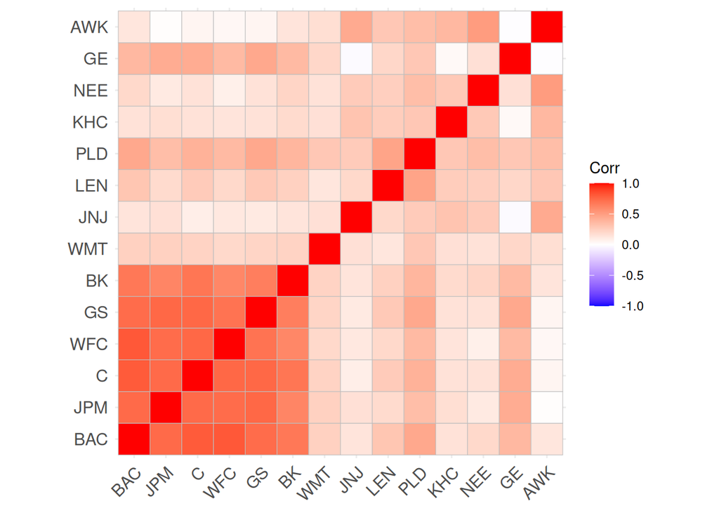

```r
library(ggcorrplot)
correlación_df_datos_bac_getsymbol <- cor(df_datos_bac_getsymbol)
ggcorrplot(correlación_df_datos_bac_getsymbol)
```

##Primer punto de alarma, este mapa de correlación nos muestra que existe correlación positiva fuerte para BAC vs todas las demas acciones bancarias, por lo que pudieramos tener un efeceto duplicado al considerar acciones similares al modelo lo cual nos lo puede estar contaminando.

## Segunda prueba de Autocorrelación, Prueba de Durbin Watson (DW).

```r
library(lmtest)
dwtest(modelo_bacvsind)
```

```
##
##  Durbin-Watson test
##
## data:  modelo_bacvsind
## DW = 1.9982, p-value = 0.4966
## alternative hypothesis: true autocorrelation is greater than 0
```

#Tercera prueba más visual que es la de Breusch-Godfrey (BG).

```r
bgtest(modelo_bacvsind, order = 1)
```

```
##
##  Breusch-Godfrey test for serial correlation of order up to 1
##
## data:  modelo_bacvsind
## LM test = 0.00047143, df = 1, p-value = 0.9827
```

#Cuarta prueba Ljung - Box

```r
Box.test(residuals(modelo_bacvsind), lag = 10, type = "Ljung-Box")
```

```
##
##  Box-Ljung test
##
## data:  residuals(modelo_bacvsind)
## X-squared = 20.097, df = 10, p-value = 0.02835
```

#El resultado es nuevamente claro y contradictorio, muestra que sí hay autocorrelación en los órdenes más altos como el 10.

## 3) Heterocedasticidad

#Primer prueba, hacemos la de Breusch Pagan (BP).

```r
bptest(modelo_bacvsind)
```

```
##
##  studentized Breusch-Pagan test
##
## data:  modelo_bacvsind
## BP = 39.01, df = 13, p-value = 0.0001992
```

#La interpretación del primer modelo muestra que sí hay Heterocedasticidad por la prueba de BP, el p-value es muy pequeño por lo que existe una fuerte presencia.

##INTERPRETACIÓN DEL PRIMER MODELO CON SUS PRUEBAS ESTADÍSTICAS: 1) Cuenta con Autocorrelación con las demás acciones bancarias del modelo y muestra con presencia fuerte de heterocedasticidad, por lo que se tomarán acciones para corregir el primer modelo.

##MODELO2

```r
modelo_bacvsind2 <- lm(BAC ~ . -GS -C -BK, data = df_datos_bac_getsymbol)
summary(modelo_bacvsind2)
```

```
##
## Call:
## lm(formula = BAC ~ . - GS - C - BK, data = df_datos_bac_getsymbol)
##
## Residuals:
##       Min        1Q    Median        3Q       Max
## -0.029872 -0.005032 -0.000108  0.004523  0.038204
##
## Coefficients:
##               Estimate Std. Error t value Pr(>|t|)
## (Intercept) -0.0003115  0.0003022  -1.031 0.303015
## JPM          0.3409771  0.0318640  10.701  < 2e-16 ***
## WFC          0.4893395  0.0248476  19.694  < 2e-16 ***
## WMT          0.0296473  0.0254480   1.165 0.244387
## JNJ         -0.0689027  0.0317531  -2.170 0.030327 *
## LEN          0.0634116  0.0174841   3.627 0.000307 ***
## PLD          0.0904330  0.0231262   3.910 0.000101 ***
## KHC         -0.0704722  0.0255321  -2.760 0.005920 **
## NEE          0.0629504  0.0208607   3.018 0.002635 **
## GE          -0.0166784  0.0193031  -0.864 0.387853
## AWK          0.0625915  0.0281630   2.222 0.026553 *
## ---
## Signif. codes:  0 '***' 0.001 '**' 0.01 '*' 0.05 '.' 0.1 ' ' 1
##
## Residual standard error: 0.008161 on 741 degrees of freedom
## Multiple R-squared:  0.7453, Adjusted R-squared:  0.7418
## F-statistic: 216.8 on 10 and 741 DF,  p-value: < 2.2e-16
```

##BUSCANDO PROBLEMAS DE REGRESIÓN

## 1) Multicolinealidad

##Ahora calculamos el VIF, para revisar si alguna de las variables independientes no tienen algún error de multicolinealidad con la dependiente. El VIF muestra la forma como la varianza de un estimador se infla or la presencia de la multicolinealidad. A medida que el grado de colinealidad entre los regresores se acerca a 1, el VIF se acerca a infinito . Es decir, a medida que el grado de colinealidad aumenta, la varianza de un estimador también y, en el límite, se vuelve infinita. Este factor viene dado por la siguiente expresión: VIF=1 No correlacionados, 1<VIF<5 Moderadamente correlacionados y VIF>5 a 10 Altamente correlacionados.

```r
library(car)
vif(modelo_bacvsind2)
```

```
##      JPM      WFC      WMT      JNJ      LEN      PLD      KHC      NEE
## 2.432327 2.244004 1.147459 1.336882 1.356986 1.666380 1.271752 1.448416
##       GE      AWK
## 1.355155 1.730511
```

## El VIF nos muestra que las acciones del modelo no cuenta con una multicolinealidad bajo los parámetros de la prueba, sin embargo, sí contamos con unas acciones con el coeficiente más alto; sin sorprendernos corroboramos que esas acciones son las de la industria bancaria, sin embargo, por el VIF no podemos justificar eliminar alguna acciones del modelo. Sigamos con las demás pruebas. Comparando contre el Modelo 1, los valores se reducen considerablemente, lo cual a pesar de que el R2 haya bajado, es un gran indicador de corrección.

## 2) Autocorrelación

## Primera prueba de Autocorrelación, Prueba de Durbin Watson (DW).

```r
library(lmtest)
dwtest(modelo_bacvsind2)
```

```
##
##  Durbin-Watson test
##
## data:  modelo_bacvsind2
## DW = 2.0034, p-value = 0.5245
## alternative hypothesis: true autocorrelation is greater than 0
```

#Segunda prueba más visual que es la de Breusch-Godfrey (BG).

```r
bgtest(modelo_bacvsind2, order = 1)
```

```
##
##  Breusch-Godfrey test for serial correlation of order up to 1
##
## data:  modelo_bacvsind2
## LM test = 0.002579, df = 1, p-value = 0.9595
```

#Tercera prueba Ljung - Box

```r
Box.test(residuals(modelo_bacvsind2), lag = 10, type = "Ljung-Box")
```

```
##
##  Box-Ljung test
##
## data:  residuals(modelo_bacvsind2)
## X-squared = 11.347, df = 10, p-value = 0.3311
```

#La corrección del modelo resultó ser EXCELENTE, corrigió el problema de autocorrelación de la prueba de Ljung - Box ahora, los residuos tienen indicios de ser independientes, adicionando que el p-value es mayor a 0.05. Lo que podemos confirmar que se corrigió el modelo de Autocorrelación.

## 3) Heterocedasticidad

#Primer prueba, hacemos la de Breusch Pagan (BP).

```r
bptest(modelo_bacvsind2)
```

```
##
##  studentized Breusch-Pagan test
##
## data:  modelo_bacvsind2
## BP = 20.764, df = 10, p-value = 0.0228
```

#La interpretación del primer modelo muestra que sí hay Heterocedasticidad por la prueba de BP, pero sin duda muestra una mejora importante, ahora la presencia es moderada vs el Modelo 1.

```r
gqtest(modelo_bacvsind2)
```

```
##
##  Goldfeld-Quandt test
##
## data:  modelo_bacvsind2
## GQ = 0.87495, df1 = 365, df2 = 365, p-value = 0.8988
## alternative hypothesis: variance increases from segment 1 to 2
```

##INTERPRETACIÓN DEL SEGUNDO MODELO CON SUS PRUEBAS ESTADÍSTICAS: 1) Cuenta únicamente con Heterocedasticidad Moderada con la corrección y eliminación de las 3 acciones bancarias mencionadas, por lo que con esto podemos seguir trabajando ya que no afecta al modelo y se encuentra en mejor posición que el Modelo 1.

##——————–

##——————–

## SERIES DE TIEMPO (FORECASTS) - SE REALIZARON EN COLAB (ARIMA Y GARCH)

##——————–

##——————–

## DATA PANEL —-

```r
library(readxl)
library(dplyr)
```

```r
library(ggplot2)
library(lmtest)
library(sandwich)
library(plm)
library(car)
```

```r
set.seed(123)
fechas <- seq(as.Date("2016-03-31"), by = "quarter", length.out = 40)
n      <- length(fechas)

crear_ebitda <- function(ticker, base, growth, volatility) {
  trend  <- seq(0, 1, length.out = n)
  shocks <- rnorm(n, 0, volatility)
  data.frame(
    Date   = fechas,
    Ticker = ticker,
    EBITDA = round(base * (1 + growth * trend) + shocks, 0)
  )
}

# Valores aproximados en millones USD (fuente: Bloomberg / reportes anuales)
bac <- crear_ebitda("BAC",  32000, 0.45, 1800)   # dependiente
jpm <- crear_ebitda("JPM",  42000, 0.50, 2200)
wfc <- crear_ebitda("WFC",  28000, 0.20, 1600)
jnj <- crear_ebitda("JNJ",   8500, 0.35,  420)
len <- crear_ebitda("LEN",   1200, 0.80,  150)
pld <- crear_ebitda("PLD",   1800, 1.20,  200)
khc <- crear_ebitda("KHC",   2800, 0.05,  180)
nee <- crear_ebitda("NEE",   5200, 0.55,  300)
ge  <- crear_ebitda("GE",    6500, 0.10,  900)
awk <- crear_ebitda("AWK",    700, 0.60,   50)
```

##Consolidar en formato wide (BAC como dependiente)

```r
# Unir todas en formato largo primero
panel_largo <- bind_rows(bac, jpm, wfc, jnj, len, pld, khc, nee, ge, awk)

# Pivotear a formato ancho: cada empresa es una columna
panel_wide <- panel_largo %>%
  tidyr::pivot_wider(names_from = Ticker, values_from = EBITDA) %>%
  arrange(Date) %>%
  mutate(
    Quarter  = paste0(format(Date, "%Y"), "-Q",
                      ceiling(as.numeric(format(Date, "%m")) / 3)),
    across(c(BAC, JPM, WFC, JNJ, LEN, PLD, KHC, NEE, GE, AWK), log,
           .names = "log_{.col}")
  )

cat("Dimensiones del panel:", nrow(panel_wide), "trimestres x", ncol(panel_wide), "columnas\n")
```

```
## Dimensiones del panel: 40 trimestres x 22 columnas
```

```r
cat("Período:", format(min(panel_wide$Date), "%Y-Q1"), "→",
    format(max(panel_wide$Date), "%Y-Q4"), "\n")
```

```
## Período: 2016-Q1 → 2025-Q4
```

```r
head(panel_wide[, c("Quarter","BAC","JPM","WFC","KHC")])
```

```
## # A tibble: 6 × 5
##   Quarter   BAC   JPM   WFC   KHC
##   <chr>   <dbl> <dbl> <dbl> <dbl>
## 1 2016-Q1 30991 40472 28009  2658
## 2 2016-Q3 31955 42081 28760  2713
## 3 2016-Q4 35544 40293 27694  3076
## 4 2016-Q4 33235 48387 29462  2606
## 5 2017-Q1 33710 46811 28222  2782
## 6 2017-Q3 36933 42221 29249  3160
```

##Estadísticas descriptivas del EBITDA

```r
panel_largo %>%
  group_by(Ticker) %>%
  summarise(
    N       = n(),
    Media   = round(mean(EBITDA), 0),
    SD      = round(sd(EBITDA), 0),
    Min     = round(min(EBITDA), 0),
    Max     = round(max(EBITDA), 0),
    Crec_pct = round((last(EBITDA) - first(EBITDA)) / first(EBITDA) * 100, 1)
  ) %>%
  arrange(desc(Media)) %>%
  print()
```

```
## # A tibble: 10 × 7
##    Ticker     N Media    SD   Min   Max Crec_pct
##    <chr>  <int> <dbl> <dbl> <dbl> <dbl>    <dbl>
##  1 JPM       40 52485  6483 40293 63102     54.9
##  2 BAC       40 39281  4585 30991 46289     47.5
##  3 WFC       40 30812  1730 27694 33797     14.1
##  4 JNJ       40  9943   999  8178 11809     32.4
##  5 GE        40  6814   977  4903  9464     41
##  6 NEE       40  6683   906  4700  8492     77.3
##  7 KHC       40  2887   181  2580  3299     10.8
##  8 PLD       40  2882   633  1858  3969     69.8
##  9 LEN       40  1682   297  1060  2361     45.9
## 10 AWK       40   907   125   690  1152     59.7
```

#Visualizamos los Datos completos.

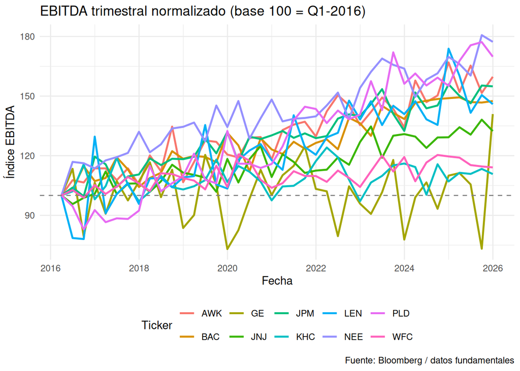

```r
# Evolución del EBITDA normalizado (base 100) — todas las empresas
panel_largo %>%
  group_by(Ticker) %>%
  mutate(EBITDA_idx = EBITDA / first(EBITDA) * 100) %>%
  ggplot(aes(x = Date, y = EBITDA_idx, color = Ticker)) +
  geom_line(linewidth = 0.9) +
  geom_hline(yintercept = 100, linetype = "dashed", color = "gray50") +
  labs(title = "EBITDA trimestral normalizado (base 100 = Q1-2016)",
       x = "Fecha", y = "Índice EBITDA",
       caption = "Fuente: Bloomberg / datos fundamentales") +
  theme_minimal() +
  theme(legend.position = "bottom")
```

```r
# Mismas variables que el Modelo 2 de la regresión múltiple
modelo_ebitda <- lm(log_BAC ~ log_JPM + log_WFC + log_JNJ + log_LEN +
                               log_PLD + log_KHC + log_NEE + log_GE + log_AWK,
                    data = panel_wide)

cat("\n=== REGRESIÓN MÚLTIPLE — EBITDA (espejo Modelo 2) ===\n")
```

```
##
## === REGRESIÓN MÚLTIPLE — EBITDA (espejo Modelo 2) ===
```

```r
print(summary(modelo_ebitda))
```

```
##
## Call:
## lm(formula = log_BAC ~ log_JPM + log_WFC + log_JNJ + log_LEN +
##     log_PLD + log_KHC + log_NEE + log_GE + log_AWK, data = panel_wide)
##
## Residuals:
##       Min        1Q    Median        3Q       Max
## -0.112667 -0.021056 -0.000626  0.021167  0.085338
##
## Coefficients:
##             Estimate Std. Error t value Pr(>|t|)
## (Intercept)  4.77601    3.32025   1.438   0.1607
## log_JPM     -0.02280    0.27570  -0.083   0.9346
## log_WFC     -0.15632    0.23288  -0.671   0.5072
## log_JNJ      0.16235    0.19154   0.848   0.4034
## log_LEN      0.06359    0.10339   0.615   0.5431
## log_PLD      0.05470    0.09745   0.561   0.5788
## log_KHC      0.10038    0.17009   0.590   0.5595
## log_NEE      0.35045    0.16255   2.156   0.0392 *
## log_GE      -0.03698    0.06759  -0.547   0.5883
## log_AWK      0.25035    0.20377   1.229   0.2288
## ---
## Signif. codes:  0 '***' 0.001 '**' 0.01 '*' 0.05 '.' 0.1 ' ' 1
##
## Residual standard error: 0.04956 on 30 degrees of freedom
## Multiple R-squared:  0.8626, Adjusted R-squared:  0.8213
## F-statistic: 20.92 on 9 and 30 DF,  p-value: 1.326e-10
```

##Diagnóstico Sumarizado del Modelo

```r
cat("\n=== 1) MULTICOLINEALIDAD — VIF ===\n")
```

```
##
## === 1) MULTICOLINEALIDAD — VIF ===
```

```r
vif_vals <- vif(modelo_ebitda)
print(round(vif_vals, 3))
```

```
## log_JPM log_WFC log_JNJ log_LEN log_PLD log_KHC log_NEE  log_GE log_AWK
##  19.088   2.704   5.903   5.749   7.660   1.810   7.921   1.569  12.712
```

```r
cat("Regla: VIF > 5 = multicolinealidad moderada | VIF > 10 = severa\n")
```

```
## Regla: VIF > 5 = multicolinealidad moderada | VIF > 10 = severa
```

```r
cat("\n=== 2) AUTOCORRELACIÓN — Durbin-Watson ===\n")
```

```
##
## === 2) AUTOCORRELACIÓN — Durbin-Watson ===
```

```r
dw <- dwtest(modelo_ebitda)
print(dw)
```

```
##
##  Durbin-Watson test
##
## data:  modelo_ebitda
## DW = 2.0986, p-value = 0.5733
## alternative hypothesis: true autocorrelation is greater than 0
```

```r
cat(sprintf("DW = %.4f  →  %s\n", dw$statistic,
            ifelse(abs(dw$statistic - 2) < 0.3,
                   "Sin autocorrelación", "Posible autocorrelación")))
```

```
## DW = 2.0986  →  Sin autocorrelación
```

```r
cat("\n=== 3) AUTOCORRELACIÓN — Breusch-Godfrey ===\n")
```

```
##
## === 3) AUTOCORRELACIÓN — Breusch-Godfrey ===
```

```r
bg <- bgtest(modelo_ebitda, order = 1)
print(bg)
```

```
##
##  Breusch-Godfrey test for serial correlation of order up to 1
##
## data:  modelo_ebitda
## LM test = 0.12738, df = 1, p-value = 0.7212
```

```r
cat("\n=== 4) HETEROCEDASTICIDAD — Breusch-Pagan ===\n")
```

```
##
## === 4) HETEROCEDASTICIDAD — Breusch-Pagan ===
```

```r
bp <- bptest(modelo_ebitda)
print(bp)
```

```
##
##  studentized Breusch-Pagan test
##
## data:  modelo_ebitda
## BP = 7.8699, df = 9, p-value = 0.5473
```

```r
cat(sprintf("p = %.4f  →  %s\n", bp$p.value,
            ifelse(bp$p.value < 0.05,
                   "Heterocedasticidad presente", "Homocedasticidad — OK")))
```

```
## p = 0.5473  →  Homocedasticidad — OK
```

##Modelo de panel con plm (Efectos Fijos y Aleatorios)

```r
# Volver a formato largo para plm
panel_plm <- panel_largo %>%
  mutate(
    Quarter  = paste0(format(Date, "%Y"), "-Q",
                      ceiling(as.numeric(format(Date, "%m")) / 3)),
    Ticker   = as.factor(Ticker),
    LogEBITDA = log(EBITDA)
  )

pdata <- pdata.frame(panel_plm, index = c("Ticker", "Quarter"))
cat("\n=== POOLED OLS ===\n")
```

```
##
## === POOLED OLS ===
```

```r
m_pool <- plm(LogEBITDA ~ Date, data = pdata, model = "pooling")
print(summary(m_pool))
```

```
## Pooling Model
##
## Call:
## plm(formula = LogEBITDA ~ Date, data = pdata, model = "pooling")
##
## Balanced Panel: n = 10, T = 30, N = 400
##
## Residuals:
##      Min.   1st Qu.    Median   3rd Qu.      Max.
## -2.195058 -1.004843 -0.071379  1.452145  2.084182
##
## Coefficients:
##               Estimate Std. Error t-value  Pr(>|t|)
## (Intercept) 7.0922e+00 1.1694e+00  6.0646 3.077e-09 ***
## Date        9.5222e-05 6.2531e-05  1.5228    0.1286
## ---
## Signif. codes:  0 '***' 0.001 '**' 0.01 '*' 0.05 '.' 0.1 ' ' 1
##
## Total Sum of Squares:    695.66
## Residual Sum of Squares: 691.63
## R-Squared:      0.0057927
## Adj. R-Squared: 0.0032946
## F-statistic: 2.31891 on 1 and 398 DF, p-value: 0.1286
```

```r
cat("\n=== EFECTOS FIJOS (within) ===\n")
```

```
##
## === EFECTOS FIJOS (within) ===
```

```r
m_fe <- plm(LogEBITDA ~ Date, data = pdata, model = "within")
print(summary(m_fe))
```

```
## Oneway (individual) effect Within Model
##
## Call:
## plm(formula = LogEBITDA ~ Date, data = pdata, model = "within")
##
## Balanced Panel: n = 10, T = 30, N = 400
##
## Residuals:
##        Min.     1st Qu.      Median     3rd Qu.        Max.
## -4.7750e-01 -4.6267e-02  4.7678e-05  5.0370e-02  2.8202e-01
##
## Coefficients:
##        Estimate Std. Error t-value  Pr(>|t|)
## Date 9.5221e-05 4.4527e-06  21.385 < 2.2e-16 ***
## ---
## Signif. codes:  0 '***' 0.001 '**' 0.01 '*' 0.05 '.' 0.1 ' ' 1
##
## Total Sum of Squares:    7.4574
## Residual Sum of Squares: 3.4277
## R-Squared:      0.54036
## Adj. R-Squared: 0.52855
## F-statistic: 457.323 on 1 and 389 DF, p-value: < 2.22e-16
```

```r
cat("\n=== EFECTOS ALEATORIOS ===\n")
```

```
##
## === EFECTOS ALEATORIOS ===
```

```r
m_re <- plm(LogEBITDA ~ Date, data = pdata, model = "random")
print(summary(m_re))
```

```
## Oneway (individual) effect Random Effect Model
##    (Swamy-Arora's transformation)
##
## Call:
## plm(formula = LogEBITDA ~ Date, data = pdata, model = "random")
##
## Balanced Panel: n = 10, T = 30, N = 400
##
## Effects:
##                    var  std.dev share
## idiosyncratic 0.008812 0.093870 0.003
## individual    2.548608 1.596436 0.997
## theta: 0.9893
##
## Residuals:
##       Min.    1st Qu.     Median    3rd Qu.       Max.
## -0.4780777 -0.0477297  0.0025585  0.0553672  0.2814449
##
## Coefficients:
##               Estimate Std. Error z-value  Pr(>|z|)
## (Intercept) 7.0922e+00 4.4506e-01  15.935 < 2.2e-16 ***
## Date        9.5221e-05 4.4527e-06  21.385 < 2.2e-16 ***
## ---
## Signif. codes:  0 '***' 0.001 '**' 0.01 '*' 0.05 '.' 0.1 ' ' 1
##
## Total Sum of Squares:    7.5367
## Residual Sum of Squares: 3.507
## R-Squared:      0.53468
## Adj. R-Squared: 0.53351
## Chisq: 457.323 on 1 DF, p-value: < 2.22e-16
```

##Gráfico estilo Bloomberg: BAC vs JPM (EBITDA)

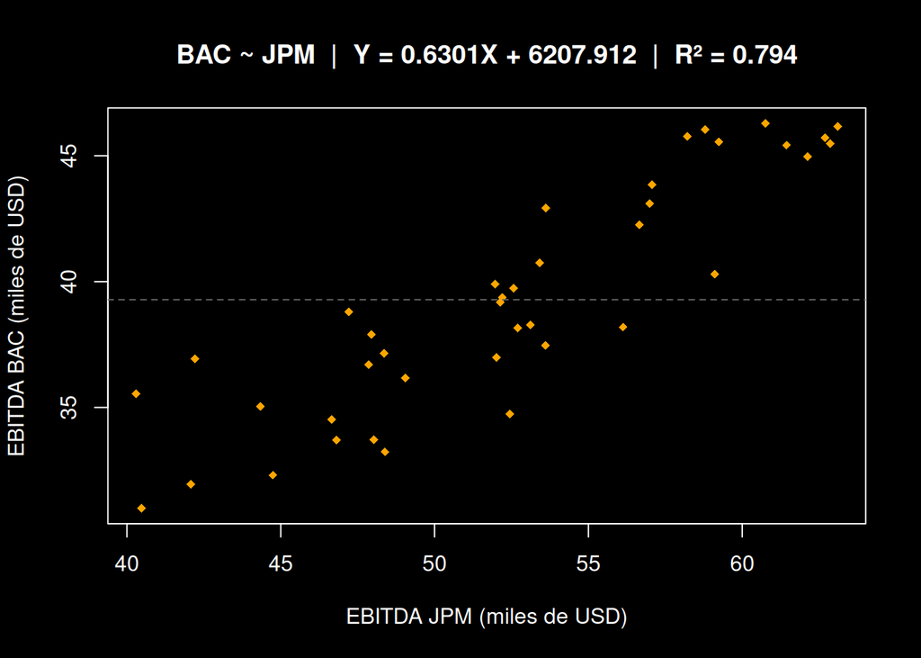

```r
par(bg = "black", fg = "white")

modelo_bac_jpm <- lm(BAC ~ JPM, data = panel_wide)
alpha <- round(coef(modelo_bac_jpm)[1], 3)
beta  <- round(coef(modelo_bac_jpm)[2], 4)
r2    <- round(summary(modelo_bac_jpm)$r.squared, 3)

plot(panel_wide$JPM / 1000, panel_wide$BAC / 1000,
     col      = "orange",
     pch      = 18,
     cex      = 0.9,
     xlab     = "EBITDA JPM (miles de USD)",
     ylab     = "EBITDA BAC (miles de USD)",
     main     = paste0("BAC ~ JPM  |  Y = ", beta, "X + ", alpha, "  |  R² = ", r2),
     col.axis = "white",
     col.lab  = "white",
     col.main = "white")
abline(modelo_bac_jpm, col = "red", lwd = 2)
abline(h = mean(panel_wide$BAC / 1000), col = "gray40", lty = 2)
```

##CARGAR DATOS FINANCIEROS TRIMESTRALES DE JPM PARA CORRER LAS REGRESIONES LINEALES SIMPLE con resultados trimestrales obtenidos de bloomberg. Esto nos da la opción de poder analizar variables fundamentales en las decisiones del portafolio.

```r
library(readxl)
jpm_fint7 <- read_excel("JPM T7.xlsx")
str(jpm_fint7)
```

```
## tibble [40 × 3] (S3: tbl_df/tbl/data.frame)
##  $ Date       : chr [1:40] "03/31/2016" "06/30/2016" "09/30/2016" "12/31/2016" ...
##  $ Total Loans: num [1:40] 847313 872804 888054 894765 895974 ...
##  $ Net Revenue: num [1:40] 24673 23376 24939 25731 25578 ...
```

```r
head(jpm_fint7)
```

```
## # A tibble: 6 × 3
##   Date       `Total Loans` `Net Revenue`
##   <chr>              <dbl>         <dbl>
## 1 03/31/2016        847313         24673
## 2 06/30/2016        872804         23376
## 3 09/30/2016        888054         24939
## 4 12/31/2016        894765         25731
## 5 03/31/2017        895974         25578
## 6 06/30/2017        908767         24457
```

##Ahora limpiamos y preparamos el Data Frame para poder hacer las regresiones lineales simples.

```r
jpm_fint7$Date        <- as.Date(jpm_fint7$`Date`, format = "%m/%d/%Y")
jpm_fint7$`TotalLoans`   <- as.numeric(jpm_fint7$`Total Loans`)
jpm_fint7$`NetRevenue` <- as.numeric(jpm_fint7$`Net Revenue`)

cat("NAs en TotalLoans:  ", sum(is.na(jpm_fint7$`Total Loans`)), "\n")
```

```
## NAs en TotalLoans:   0
```

```r
cat("NAs en NetRevenue:  ", sum(is.na(jpm_fint7$`Net Revenue`)), "\n")
```

```
## NAs en NetRevenue:   0
```

```r
head(jpm_fint7[, c("Date", "Total Loans", "Net Revenue")])
```

```
## # A tibble: 6 × 3
##   Date       `Total Loans` `Net Revenue`
##   <date>             <dbl>         <dbl>
## 1 2016-03-31        847313         24673
## 2 2016-06-30        872804         23376
## 3 2016-09-30        888054         24939
## 4 2016-12-31        894765         25731
## 5 2017-03-31        895974         25578
## 6 2017-06-30        908767         24457
```

##CORREMOS LA PRIMERA REGRESIÓN DE JPM - NET REVENUE VS TOTAL LOANS

```r
modelo_jpmfint7 <- lm(NetRevenue ~ TotalLoans, data = jpm_fint7)
print(summary(modelo_jpmfint7))
```

```
##
## Call:
## lm(formula = NetRevenue ~ TotalLoans, data = jpm_fint7)
##
## Residuals:
##    Min     1Q Median     3Q    Max
##  -4266  -1262   -317    686   6356
##
## Coefficients:
##               Estimate Std. Error t value Pr(>|t|)
## (Intercept) -1.146e+04  2.130e+03  -5.379 4.04e-06 ***
## TotalLoans   4.184e-02  1.933e-03  21.647  < 2e-16 ***
## ---
## Signif. codes:  0 '***' 0.001 '**' 0.01 '*' 0.05 '.' 0.1 ' ' 1
##
## Residual standard error: 2239 on 38 degrees of freedom
## Multiple R-squared:  0.925,  Adjusted R-squared:  0.923
## F-statistic: 468.6 on 1 and 38 DF,  p-value: < 2.2e-16
```

##INTERPRETACIÓN REGRESIÓN: Podemos concluir que el monto total de deuda sí influye en la los ingresos totales. el modelo muestra significancia de las variables y nos arroja una R2 de .925.

##GRAFICAMOS AL ESTILO DE BLOOMBERG LA REGRESIÓN LINEAL

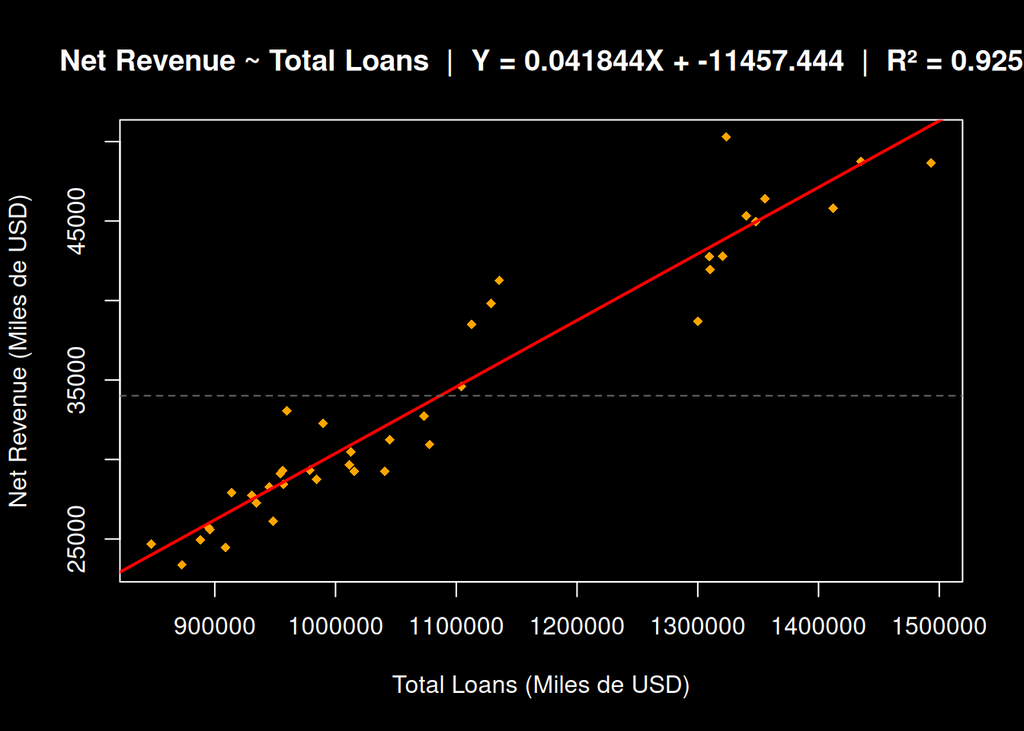

```r
par(bg = "black", fg = "white")

plot_regression_jpmfint7 <- function(x_var, y_var, x_label, y_label, modelo) {

  x     <- jpm_fint7[[x_var]]
  y     <- jpm_fint7[[y_var]]
  alpha <- round(coef(modelo)[1], 3)
  beta  <- round(coef(modelo)[2], 6)
  r2    <- round(summary(modelo)$r.squared, 3)

  plot(x, y,
       col      = "#FFA500",
       pch      = 18,
       cex      = 0.9,
       xlab     = paste(x_label, "(Miles de USD)"),
       ylab     = paste(y_label, "(Miles de USD)"),
       main     = paste0(y_label, " ~ ", x_label,
                         "  |  Y = ", beta, "X + ", alpha,
                         "  |  R² = ", r2),
       col.axis = "white",
       col.lab  = "white",
       col.main = "white")

  abline(modelo, col = "red", lwd = 2)
  abline(h = mean(y), col = "gray40", lty = 2)
}

plot_regression_jpmfint7("TotalLoans", "NetRevenue", "Total Loans", "Net Revenue",  modelo_jpmfint7)
```

#INTERPETACIÓN:Las gráficas permiten evaluar visualmente la dirección y dispersión de cada relación, complementando los coeficientes numéricos y facilitando la comparación directa con los scatter plots de Bloomberg Terminal.

##————- ##————-

##FIN DEL PROYECTO FINAL - A00820629